# Import Packages

Start by importing packages, as usual:

```python
import pandas as pd
import numpy as np
import matplotlib.pyplot as plt
import seaborn as sns
%matplotlib inline
from sklearn.ensemble import RandomForestClassifier
from sklearn.model_selection import train_test_split
from sklearn.tree import DecisionTreeClassifier
from sklearn.metrics import classification_report, confusion_matrix, accuracy_score
```

# Load in Data

```python
titanic = sns.load_dataset('titanic')
```

# Data Wrangling

### (Same as with decesion tree example)

```python
titanic = titanic.drop(['class', 'who', 'adult_male', 'deck', 'alive'], axis=1)
```

```python
titanic["age"] = titanic.groupby("pclass").transform(lambda x: x.fillna(x.mean()))['age']
```

```python
titanic['sex'] = titanic['sex'].replace(['male', 'female'], [0,1])
```

```python
titanic = pd.get_dummies(titanic)
```

```python
x = titanic.drop('survived', axis=1)
y = titanic['survived']
```

# Train Test Split

```python
x_train, x_test, y_train, y_test = train_test_split(x,y, test_size=0.3, random_state=76)
```

Random Forests among the most commonly used machine learning algotirhms. Here are some of the advantages which make it such a powerful tool:

- There are no assumptions tests for this algorithm. Hallelujah!
- You do not need to scale any of your variables. Woah!
- The default hyperparameters work quite well making it great "off the shelf"

Does it this seem to good to be true? Is there a catch? Of course, there are always pros AND cons. One of the main disadvantages is the issue of complexity. Depending on how many predictor variables, levels in catergories, size of data set, and how many decision trees used, the combinatorics of random forests can get HUGE. Remember permutations/combonations anyone?!?! So you must be concisencous of how computationally expensive your model will be (how much time it will take). After all, your time is prescious, and your supervisor at your job will more than likely be thinking, "Time is Money!"

# Initial Random Forest Model

```python
forest = RandomForestClassifier()
forest
```

```
RandomForestClassifier(bootstrap=True, class_weight=None, criterion='gini',
                       max_depth=None, max_features='auto', max_leaf_nodes=None,
                       min_impurity_decrease=0.0, min_impurity_split=None,
                       min_samples_leaf=1, min_samples_split=2,
                       min_weight_fraction_leaf=0.0, n_estimators='warn',
                       n_jobs=None, oob_score=False, random_state=None,
                       verbose=0, warm_start=False)
```

```python
forest = RandomForestClassifier()
forest.fit(x_train, y_train)
print(accuracy_score(y_test, forest.predict(x_test)))
```

```
0.8022388059701493
```

We have a 80% accuracy utilizing the "off-the-shelf" RandomForestClassifier algorithm on our titanic dataset.

A parameter in statistical modeling is a value that is created while computing your model(i.e. the slope (m) in linear regression). A hyperparameter is a value that is set PRIOR to creating your model. There are alot of hyperparameters as you can see, BUT luckily there are 4 which will have the most impact in tuning your RF model.

- max_depth: The depth size of a tree
- n_estimators: The number of trees in the forest. Generally, the more trees the better accuracy, but increases computation time.
- max_features: The max number of features that the algorithm can assign to an individual tree. Try ['auto', 'None', 'sqrt', 'log2', 0.9 and 0.2]
- min_samples_leaf: The minimum number of samples in newly created leaves. Try [1,2,3]. If 3 is best, try higher numbers.

One way to tune your hyperparameters is to do them one at a time through process of elimination. Lets start with n_estimators. When your out wokring in the field, and your training with hundreds of gigabytes of data, perhaps 500 trees is just not feasible. So, we will find the threshold of diminishing returns.

```python
n_estimators_array = [1, 4, 5, 8, 10, 20, 50, 75, 100, 250, 500]
results = []
for n in n_estimators_array:
    forest = RandomForestClassifier(n_estimators=n, random_state=76)
    forest.fit(x_train, y_train)
    result = accuracy_score(y_test, forest.predict(x_test))
    results.append(result)
    print(n, ':', result)
```

```
1 : 0.7686567164179104
4 : 0.7835820895522388
5 : 0.7947761194029851
8 : 0.8022388059701493
10 : 0.7947761194029851
20 : 0.8208955223880597
50 : 0.8134328358208955
75 : 0.8059701492537313
100 : 0.8022388059701493
250 : 0.8134328358208955
500 : 0.8097014925373134
```

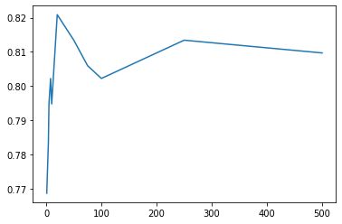

```python
plt.plot(n_estimators_array, results)
```

Looks like 20 decision trees is the sweet spot!

If your wondering, "Is there an easier way to find the best hyperparameter values without having to go through each, one at time? Is there an automated way to find em' all in one whack?" The answer is Yes! Randomized Grid Serach. And Guess what? You can use this with any algorithm in the Scikit Learn library! If thats not enough, it uses cross validation when calculating accuracy!!!

Below we are creating lists with all the hyperparameter values we want to trial. Then we are creating a dictionary with the hyperparmeter names as the keys and the list variables as the values. This is called a "grid".

```python
from sklearn.model_selection import RandomizedSearchCV
# Number of features to consider at every split
max_features = ['auto', None, 'log2']
# Maximum number of levels in tree
max_depth = [10, 20, 30, 40, 50, 60, 70, 80, 90, None]
# Minimum number of samples required at each leaf node
min_samples_leaf = [1, 2, 4]
# Method of selecting samples for training each tree
random_grid = {'max_features': max_features,
               'max_depth': max_depth,
               'min_samples_leaf': min_samples_leaf}
print(random_grid)
```

```
{'max_features': ['auto', None, 'log2'], 'max_depth': [10, 20, 30, 40, 50, 60, 70, 80, 90, None], 'min_samples_leaf': [1, 2, 4]}
```

The first line of code below initializes a random forest instance with 20 estimators (the sweet spot we found above). Next you are creating an instance of RandomizedSearchCV object, inputing random forest instance (rf) as estimator, the grid that we created(random_grid) for param_distributions, the maximum number of hyperparameter combinations for n_iter, and number the cross validation folds for cv.

```python
rf = RandomForestClassifier(n_estimators=20)
# Random search of parameters, using 3 fold cross validation,
# search across 100 different combinations, and use all available cores
rf_random = RandomizedSearchCV(estimator = rf, param_distributions = random_grid, n_iter = 90, cv = 3, random_state=42)
# Fit the random search model
rf_random.fit(x_train, y_train)
```

```
RandomizedSearchCV(cv=3, error_score='raise-deprecating',
                   estimator=RandomForestClassifier(bootstrap=True,
                                                    class_weight=None,
                                                    criterion='gini',
                                                    max_depth=None,
                                                    max_features='auto',
                                                    max_leaf_nodes=None,
                                                    min_impurity_decrease=0.0,
                                                    min_impurity_split=None,
                                                    min_samples_leaf=1,
                                                    min_samples_split=2,
                                                    min_weight_fraction_leaf=0.0,
                                                    n_estimators=20,
                                                    n_jobs=None,
                                                    oob_score=False,
                                                    random_state=None,
                                                    verbose=0,
                                                    warm_start=False),
                   iid='warn', n_iter=90, n_jobs=None,
                   param_distributions={'max_depth': [10, 20, 30, 40, 50, 60,
                                                      70, 80, 90, None],
                                        'max_features': ['auto', None, 'log2'],
                                        'min_samples_leaf': [1, 2, 4]},
                   pre_dispatch='2*n_jobs', random_state=42, refit=True,
                   return_train_score=False, scoring=None, verbose=0)
```

```python
rf_random.best_params_
```

[output not shown]

```python
forest = RandomForestClassifier(n_estimators=20, min_samples_leaf=4, max_features=None, max_depth=20)
forest.fit(x_train, y_train)
```

```
RandomForestClassifier(bootstrap=True, class_weight=None, criterion='gini',
                       max_depth=20, max_features=None, max_leaf_nodes=None,
                       min_impurity_decrease=0.0, min_impurity_split=None,
                       min_samples_leaf=4, min_samples_split=2,
                       min_weight_fraction_leaf=0.0, n_estimators=20,
                       n_jobs=None, oob_score=False, random_state=None,
                       verbose=0, warm_start=False)
```

```python
forestPredictions = forest.predict(x_test)
print(confusion_matrix(y_test, forestPredictions))
print(classification_report(y_test, forestPredictions))
```

```
[[153  12]
 [ 28  75]]
              precision    recall  f1-score   support

           0       0.85      0.93      0.88       165
           1       0.86      0.73      0.79       103

    accuracy                           0.85       268
   macro avg       0.85      0.83      0.84       268
weighted avg       0.85      0.85      0.85       268
```

With tuning our hyperparameters using a randomized grid search, we were able to increase our accuracy by 5%. NICE!!!

There is one more really cool thing that the sklearn.randomforestclassifier has. We an order of how important each feature was to the accuracy our model!

```python
feature_importances = pd.Series(forest.feature_importances_, index=x.columns)
feature_importances
```

```
pclass                     0.136232
sex                        0.381470
age                        0.175076
sibsp                      0.026099
parch                      0.010987
fare                       0.228564
alone                      0.005504
embarked_C                 0.007292
embarked_Q                 0.004684
embarked_S                 0.009365
embark_town_Cherbourg      0.005118
embark_town_Queenstown     0.002453
embark_town_Southampton    0.007157
dtype: float64
```

Below is a little extra code to get "embarked" and "embark_town" back to one feature and then and sort them from most important to least important :)

```python
embarked_importance = feature_importances[[i for i in feature_importances.index if "embarked" in i]].sum()
embarked_importance
```

```
0.021340168601613647
```

```python
embarked_town_importance = feature_importances[[i for i in feature_importances.index if "embark_town" in i]].sum()
embarked_town_importance
```

```
0.014727362761250737
```

```python
feature_importances = feature_importances[[i for i in feature_importances.index if "embarked" not in i and "embark_town" not in i]]
feature_importances['embarked'] = embarked_importance
feature_importances['embark_town'] = embarked_town_importance
```

```
sex            0.381470
fare           0.228564
age            0.175076
pclass         0.136232
sibsp          0.026099
embarked       0.021340
embark_town    0.014727
parch          0.010987
alone          0.005504
dtype: float64
```

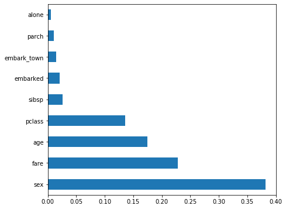

```python
feature_importances.sort_values(inplace=True, ascending=False)
print(feature_importances)
feature_importances.plot(kind='barh', figsize=(7,6))
```